# Part I homework 2

Elisa Battista, Simone Cuonzo, Lorenzo Di Giannantonio

2025-01-10

The paper “Adaptive Conformal Inference Under Distribution Shift” by Gibbs and Candès addresses a critical challenge in modern machine learning: constructing prediction sets that maintain a desired coverage frequency when the underlying data distribution evolves over time. The authors focus on an online learning scenario, where covariate-response pairs arrive sequentially. Unlike traditional conformal inference methods that rely on the assumption of exchangeability, ACI adapts dynamically to non-stationary environments, ensuring robust performance under distributional shifts.

ACI provides a powerful and general methodology for transforming the outputs of any black-box prediction algorithm into prediction sets with valid coverage guarantees. Crucially, it is compatible with a wide range of machine learning models capable of producing either point predictions or quantile estimates, thereby enabling its application across diverse domains.

This paper introduces ACI as a method for forming prediction sets that are inherently robust to changes in the marginal distribution of the data. The approach is both conceptually simple and practically effective. It requires tracking only a single parameter that dynamically models distributional shifts, making it computationally efficient and easy to implement. Moreover, ACI’s generality allows it to seamlessly integrate with any modern machine learning algorithm capable of providing either point predictions or estimated quantiles.

Over long time intervals, ACI achieves the desired target coverage frequency without making strong assumptions about the underlying data-generating process. Additionally, when the distribution shift is relatively small and the prediction algorithm satisfies certain regularity conditions, ACI achieves approximate marginal coverage at most individual time steps. This dual capability—ensuring long-term coverage while adapting to immediate changes—positions ACI as a crucial tool for reliable prediction in evolving data environments.

In the context of regression modeling, **Conformal Inference** provides a powerful framework for constructing prediction sets that guarantee coverage for new observations with a specified confidence level. Given a fitted regression model that predicts the value of $Y$ from the features $X$, Conformal Inference aims to determine whether a candidate value $y$ for $Y_t$ is a reasonable estimate.

To assess the reasonableness of $y$, we define a **conformity score** $S(X, Y)$, which measures how well the candidate value $y$ conforms to the model’s predictions. If the regression model provides point predictions $\hat{\mu}(X)$, the conformity score is the absolute distance between the predicted value and the candidate:

$$S(X_t, y) = |\hat{\mu}(X_t) - y|$$

Alternatively, for quantile regression models that predict quantiles of the conditional distribution of $Y$ given $X$, a conformity score can be defined as the signed distance between $y$ and the fitted quantiles:

$$S(X_t, y) = \max \left\{ \hat{q}(X_t; \alpha/2) - y, y - \hat{q}(X_t;
1-\alpha/2) \right\}$$

where $\hat{q}(X_t; \alpha/2)$ and $\hat{q}(X_t; 1-\alpha/2)$ are the estimated lower and upper $\alpha$-quantiles of $Y_t$, respectively.

The goal is to determine how small the conformity score $S(X_t, y)$ should be in order for $y$ to be considered a reasonable prediction for $Y_t$. To this end, we employ a **calibration set** $D_{\text{cal}} \subseteq \{ (X_r, Y_r) \}_{1 \leq r \leq t-1}$ that is distinct from the training data used to fit the model. Using this calibration set, we define the empirical quantiles of the conformity scores as:

$$\hat{Q}(p) := \inf \left\{ s : \frac{1}{|D_{\text{cal}}|} \sum_{(X_r,
Y_r) \in D_{\text{cal}}} \mathbb{I}(S(X_r, Y_r) \leq s) \geq p \right\}$$

where $\mathbb{I}$ denotes the indicator function, and $\hat{Q}(p)$ represents the $p$-th quantile of the conformity scores in the calibration set. A value $y$ is considered a reasonable prediction for $Y_t$ if its conformity score satisfies:

$$S(X_t, y) \leq \hat{Q}(1-\alpha)$$

The key observation is that if the data $D_{\text{cal}} \cup \{(X_t, Y_t)\}$ are exchangeable, the rank of $S(X_t, Y_t)$ among the conformity scores $\{ S(X_r, Y_r) \}_{(X_r, Y_r) \in D_{\text{cal}} \cup \{(X_t, Y_t)\}}$ will follow a uniform distribution. Therefore, the probability that $S(X_t, Y_t)$ is less than or equal to $\hat{Q}(1-\alpha)$ is given by:

$$P(S(X_t, Y_t) \leq \hat{Q}(1-\alpha)) = \frac{\left\lceil
|D_{\text{cal}}|(1-\alpha) \right\rceil}{|D_{\text{cal}}| + 1}$$

Thus, the prediction set $C_t$ can be defined as:

$$C_t := \{ y : S(X_t, y) \leq \hat{Q}(1-\alpha) \}$$

which guarantees a marginal coverage probability of:

$$P(Y_t \in C_t) = P(S(X_t, Y_t) \leq \hat{Q}(1-\alpha)) =
\frac{\left\lceil |D_{\text{cal}}|(1-\alpha)
\right\rceil}{|D_{\text{cal}}| + 1}$$

This procedure is known as **split conformal inference**, as it relies on splitting the data into a training set and a calibration set. The method can be further adjusted to work without data splitting, known as **full conformal inference**, although this requires greater computational resources.

In the previous section, we assumed a stationary distribution for the data, which allowed us to estimate a single score function $S(\cdot)$ and quantile function $\hat{Q}(\cdot)$. However, in real-world scenarios, the distribution of data may change over time. As a result, both the score function and the quantile function need to be updated regularly to align with the most recent observations.

At each time $t$, we assume that a fitted score function $S_t(\cdot)$ and corresponding quantile function $\hat{Q}_t(\cdot)$ are available. The **miscoverage rate** for a prediction set is the probability that the true value of the response variable $Y_t$ does not lie within the prediction set $\hat{C}_t(\alpha)$ at time $t$.

At each time $t$, we assume that a fitted score function $S_t(\cdot)$ and corresponding quantile function $\hat{Q}_t(\cdot)$ are available. The **realized miscoverage rate** of the prediction set $\hat{C}_t(\alpha) := \{y : S_t(X_t, y) \leq \hat{Q}_t(1 - \alpha)\}$ is defined as:

$$M_t(\alpha) := P(S_t(X_t, Y_t) > \hat{Q}_t(1 - \alpha))$$

where the probability is taken over the test point $(X_t, Y_t)$ as well as the data used to fit $S_t(\cdot)$ and $\hat{Q}_t(\cdot)$.

Since the data distribution is non-stationary, we do not expect $M_t(\alpha)$ to be equal, or even close to, $\alpha$. Nonetheless, we hypothesize that if the conformity scores used to fit $\hat{Q}_t(\cdot)$ cover the bulk of the distribution of $S_t(X_t, Y_t)$, then there may exist an alternative value $\alpha_t^* \in [0, 1]$ such that $M_t(\alpha_t^*) \approx \alpha$.

To formalize this, we assume that, with probability one, $\hat{Q}_t(\cdot)$ is continuous and non-decreasing, with $\hat{Q}_t(0) = -1$ and $\hat{Q}_t(1) = 1$. This is not the case for the split conformal quantile functions defined previously, but in the absence of ties among the conformity scores, we can adjust our definition to ensure continuity by smoothing over any jump discontinuities in $\hat{Q}_t(\cdot)$. Under these conditions, $M_t(\alpha)$ will be non-decreasing on $[0, 1]$ with $M_t(0) = 0$ and $M_t(1) = 1$, allowing us to define:

$$\alpha_t^* := \sup\left\{ \alpha \in [0, 1] : M_t(\alpha) \leq \alpha
\right\}$$
The function $\alpha_t^* := \sup\{ \alpha \in [0, 1] : M_t(\alpha) \leq \alpha \}$ defines the optimal threshold $\alpha_t^*$ for the miscoverage rate $M_t(\alpha)$, ensuring that the miscoverage rate is as close as possible to the desired level $\alpha$.

Moreover, if we assume that:

$$P(S_t(X_t, Y_t) = \hat{Q}_t(1 - \alpha_t^*)) = 0$$

This assumption is important because it ensures that the conformity score $S_t(X_t, Y_t)$ does not exactly equal the value of the conformity quantile $\hat{Q}_t(1 - \alpha_t^*)$ with positive probability.

In other words, this assumption implies that there are no “ties” (or situations of indeterminacy) where the conformity score is equal to the quantile value. If such a situation were to occur with positive probability, it would not be possible to properly calibrate the threshold for the marginal coverage.

When this assumption holds, the value $\alpha_t^*$ can be used to achieve exact or approximately exact marginal coverage equal to $\alpha$. In practice, without this assumption, there could be uncertainty in determining the value of $\alpha_t^*$, and the coverage guarantee might not be properly maintained.

To calibrate $\alpha_t^*$, we use a simple **online update**. This update procedure examines the empirical miscoverage frequency of previous prediction sets and adjusts our estimate of $\alpha_t^*$ accordingly, by increasing or decreasing it. Specifically, let $\alpha_1$ denote our initial estimate (in our experiments, we choose $\alpha_1 = \alpha$). We recursively define the sequence of miscoverage events as:

$$\text{err}_t := \begin{cases}
1 & \text{if } Y_t \notin \hat{C}_t(\alpha_t) \\
0 & \text{otherwise}
\end{cases}$$

where $\hat{C}_t(\alpha_t) := \{y : S_t(X_t, y) \leq \hat{Q}_t(1 - \alpha_t)\}$. Given a step size parameter $\delta > 0$, we consider the update:

$$\alpha_{t+1} := \alpha_t + \gamma (\alpha - \text{err}_t)$$
This formula defines the updating rule for $\alpha_t^*$, to improve the accuracy of the coverage over time.

We refer to this as **adaptive conformal inference**, where $\text{err}_t$ represents our estimate of the historical miscoverage frequency.

An alternative update rule can be defined as:

$$\alpha_{t+1} = \alpha_t + \gamma \left( \alpha - \sum_{s=1}^{t} w_s
\cdot \text{err}_s \right)$$

The weights $w_s$ are chosen so that the sum $\sum_{s=1}^{t} w_s \cdot \text{err}_s$ gives more importance to the most recent errors, reflecting the belief that errors closer to time $t$ are more relevant for updating the threshold $\alpha_t$.

A possible scheme for the weights could be:

$$w_s = \frac{0.95^{t-s}}{\sum_{s=1}^{t} 0.95^{t-s}}$$

where the weight decays exponentially as $s$ becomes smaller, meaning that more recent errors are given higher weights.

Using this formulation for the weights, the authors have noticed that the results obtained for $\alpha_t$, calculated using the two proposed update methods are very similar, the main difference is that the trajectories obtained with the second update method are smoother, with less local variation in $\alpha_t$.

For simplicity, in this article, we will focus on the first update rule.

We now focus on the choice of $\gamma$, which is crucial for balancing adaptability and stability in the update process for $\alpha_t$.

The value of $\gamma$ represents a tradeoff: increasing $\gamma$ improves the method’s adaptability to observed distributional shifts but also introduces greater volatility in $\alpha_t$. Excessive fluctuations in $\alpha_t$ can be problematic, as they may cause the method to oscillate between overly conservative and overly anti-conservative prediction sets, leading to undesirable instability.

Such instability is undesirable in practice, as it undermines the reliability of the adaptive conformal inference procedure. Therefore, selecting an appropriate value for $\gamma$ is essential to maintain stable yet responsive updates to $\alpha_t$.

```r
library(quantmod)
library(rugarch)
library(quantreg)
library(FinTS)
library(dplyr)
library(forecast)
getSymbols("MSFT", from = "2015-01-01", to = "2023-12-31")
```

```
## [1] "MSFT"
```

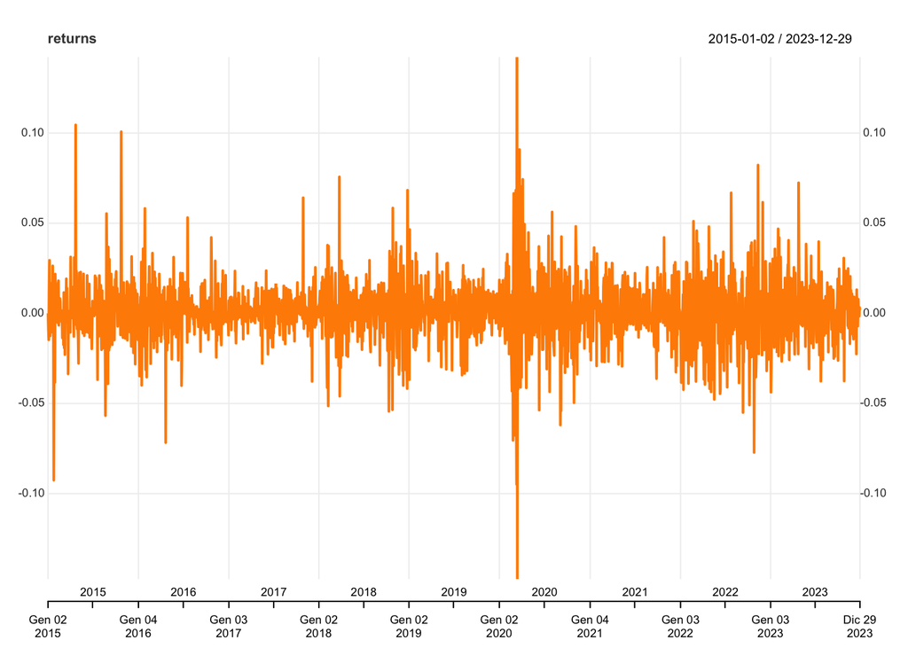

```r
msft <- Cl(MSFT)     # extracting closing prices

returns <- dailyReturn(msft)
returns <- na.omit(returns)

chart_Series(returns, main = "MSFT returns")
```

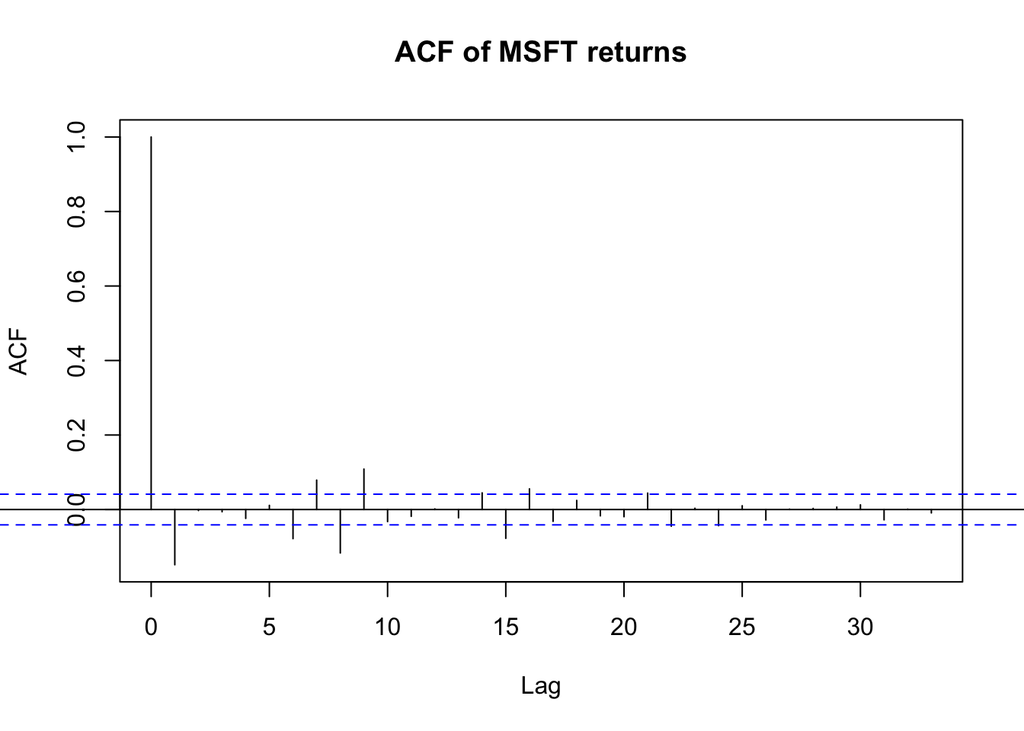

```r
acf(returns, main = "ACF of MSFT returns")
```

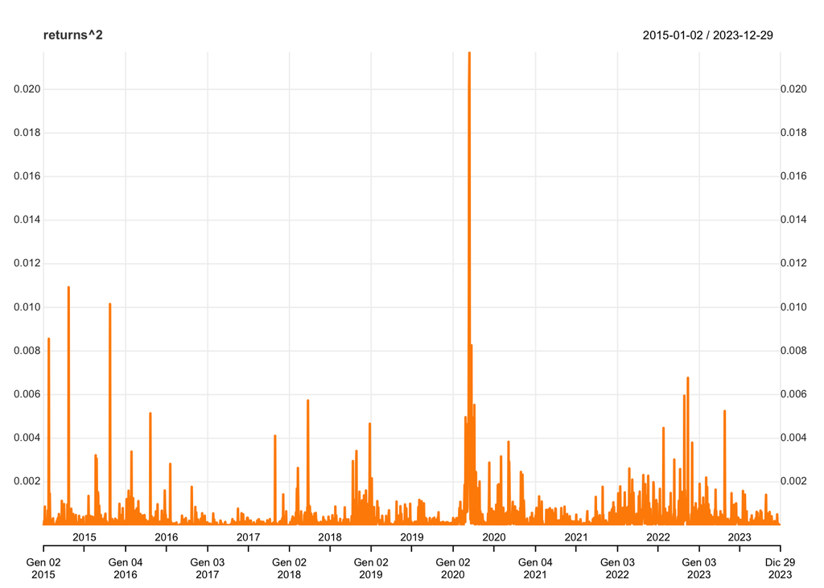

```r
chart_Series(returns^2, main = "squared returns of MSFT")
```

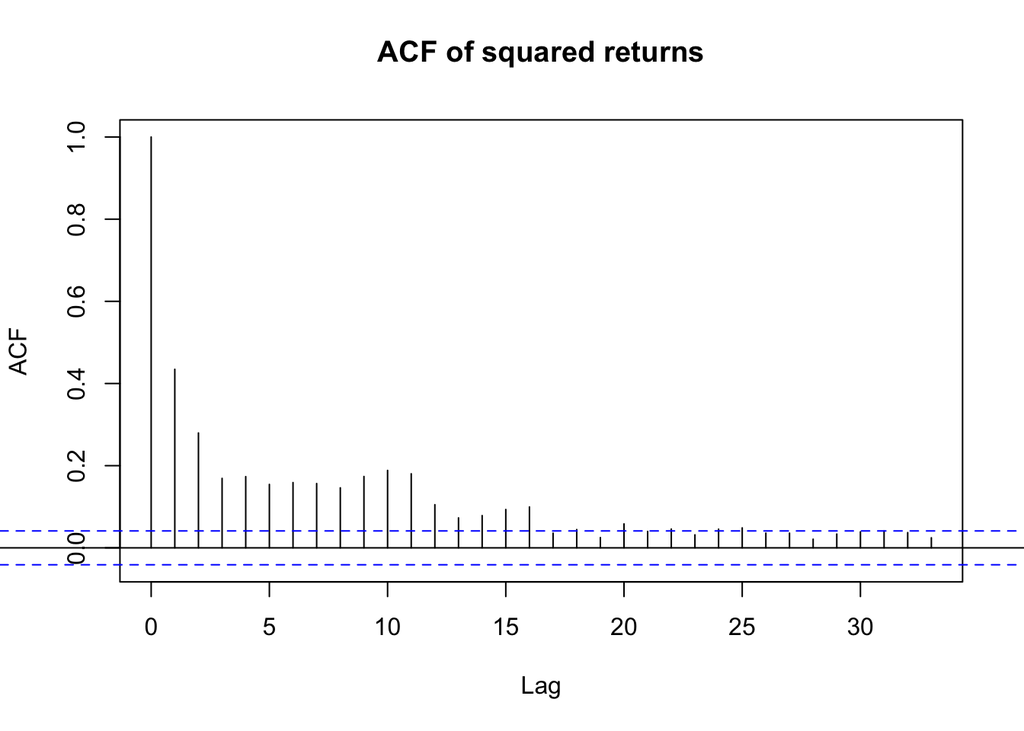

```r
acf(returns^2, main = "ACF of squared returns")
```

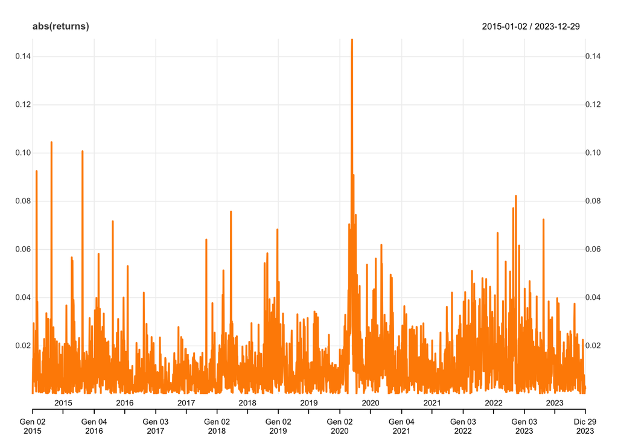

```r
chart_Series(abs(returns), main = "MSFT absolute returns")
```

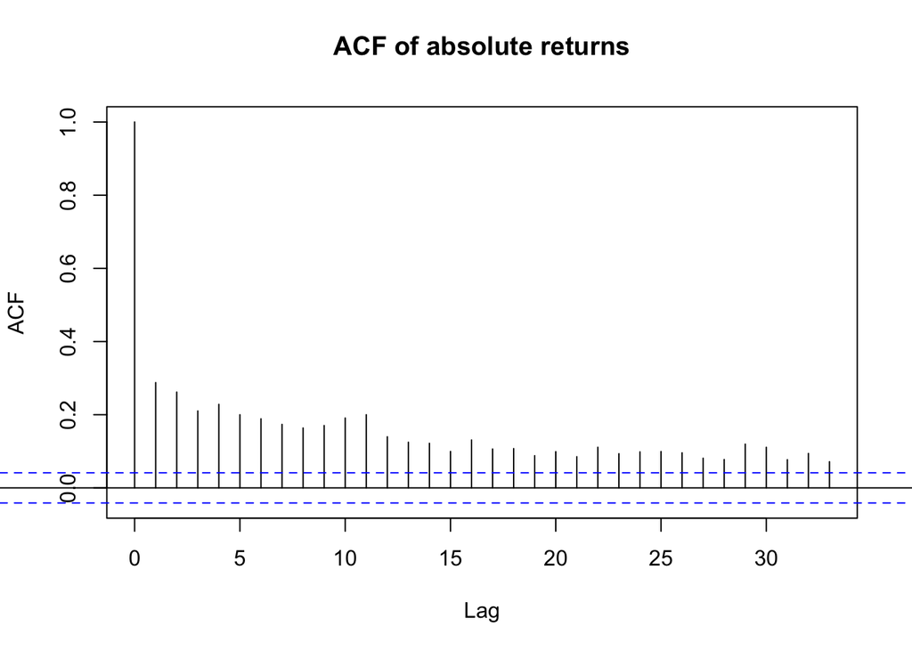

```r
acf(abs(returns), main = "ACF of absolute returns")
```

```r
# we notice serial correlation in squared and abs returns, which indicates arch effect!

Box.test(returns, type = "Ljung-Box", lag = 12)
```

```
##
##  Box-Ljung test
##
## data:  returns
## X-squared = 140.48, df = 12, p-value < 2.2e-16
```

```r
Box.test(returns^2, type = "Ljung-Box", lag = 12)
```

```
##
##  Box-Ljung test
##
## data:  returns^2
## X-squared = 1203.1, df = 12, p-value < 2.2e-16
```

```r
Box.test(abs(returns), type = "Ljung-Box", lag = 12)
```

```
##
##  Box-Ljung test
##
## data:  abs(returns)
## X-squared = 1147.6, df = 12, p-value < 2.2e-16
```

```r
# if the p value is low (<0.05) we reject the null of "no serial correlation".
# a significative result in squared returns (or abs returns) supports the necessity of a GARCH model.

fit_arima <- auto.arima(returns)
summary(fit_arima)
```

```
## Series: returns
## ARIMA(3,0,5) with non-zero mean
##
## Coefficients:
##           ar1     ar2     ar3     ma1      ma2      ma3     ma4     ma5    mean
##       -0.7859  0.7743  0.8402  0.6554  -0.9050  -0.7865  0.0815  0.0555  0.0011
## s.e.   0.0540  0.0606  0.0407  0.0567   0.0619   0.0445  0.0292  0.0281  0.0002
##
## sigma^2 = 0.0002939:  log likelihood = 5997.47
## AIC=-11974.94   AICc=-11974.84   BIC=-11917.69
##
## Training set error measures:
##                         ME       RMSE        MAE MPE MAPE      MASE
## Training set -1.878507e-05 0.01711066 0.01192631 NaN  Inf 0.6558746
##                      ACF1
## Training set -0.002029582
```

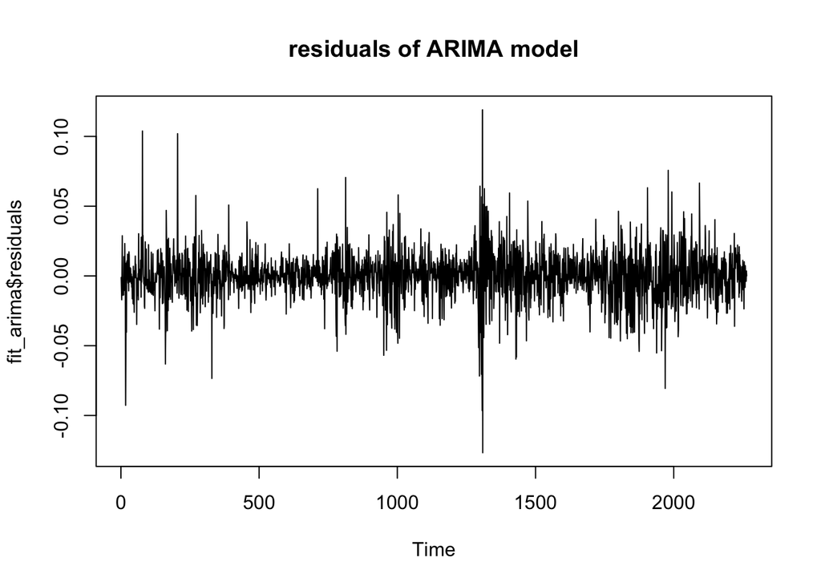

```r
plot(fit_arima$residuals, main = "residuals of ARIMA model")
```

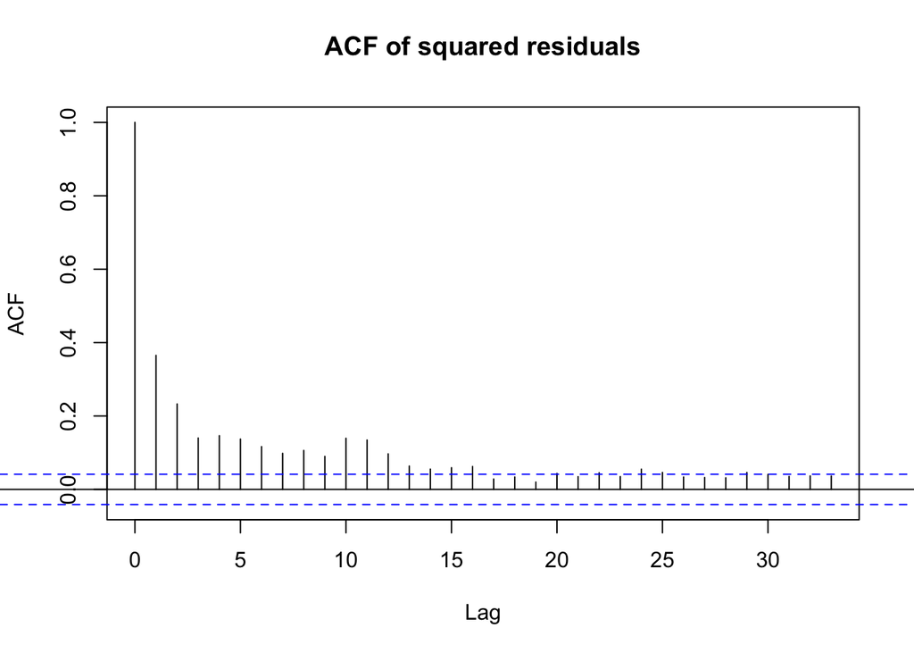

```r
acf(fit_arima$residuals^2, main = "ACF of squared residuals")
```

```r
# we can notice volatility clusters in the residuals
# suggesting an ARCH/GARCH model, rather than ARIMA

ArchTest(returns, lags = 12, demean = FALSE)
```

```
##
##  ARCH LM-test; Null hypothesis: no ARCH effects
##
## data:  returns
## Chi-squared = 507.72, df = 12, p-value < 2.2e-16
```

```r
# p < 0.05: we reject the null of no ARCH effects, so ARCH exists
```

In the initial part of the code we start by selecting the data we need, do the manipulations to get the returns and start with the analysis that allow us to understand and prove that we have ARCH effects: first we simply plot the returns (and their square) and the ACF just to have a look at the series and then we perform some statistical test. The result is that data show some volatility clustering and this tells us that it is correct to use an ARCH/GARCH model.

```r
models <- list(
  list(variance = "sGARCH", dist = "norm"),
  list(variance = "sGARCH", dist = "std"),
  list(variance = "sGARCH", dist = "ged"),
  list(variance = "eGARCH", dist = "norm"),
  list(variance = "eGARCH", dist = "std"),
  list(variance = "eGARCH", dist = "ged"),
  list(variance = "apARCH", dist = "norm"),
  list(variance = "apARCH", dist = "std"),
  list(variance = "apARCH", dist = "ged")
)

model_results <- list()

for (i in seq_along(models)) {
  model_spec <- ugarchspec(
    variance.model = list(model = models[[i]]$variance, garchOrder = c(1, 1)),
    mean.model = list(armaOrder = c(0, 0), include.mean = FALSE),
    distribution.model = models[[i]]$dist
  )

  # model estimation
  model_fit <- ugarchfit(spec = model_spec, data = returns)

  # saving the results
  model_results[[i]] <- list(
    spec = models[[i]],
    fit = model_fit,
    aic = infocriteria(model_fit)["Akaike", 1],
    bic = infocriteria(model_fit)["Bayes", 1],
    loglik = likelihood(model_fit),
    residuals = residuals(model_fit, standardize = TRUE)
  )
}
 #data frame for the comparison
comparison <- data.frame(
  Model = sapply(model_results, function(x) paste0(x$spec$variance, "-", x$spec$dist)),
  AIC = sapply(model_results, function(x) x$aic),
  BIC = sapply(model_results, function(x) x$bic),
  LogLikelihood = sapply(model_results, function(x) x$loglik)
)

#sorting models by AIC
comparison <- comparison[order(comparison$AIC), ]
print("Confronto tra i modelli:")
```

```
## [1] "Confronto tra i modelli:"
```

```r
print(comparison)
```

```
##         Model       AIC       BIC LogLikelihood
## 8  apARCH-std -5.607967 -5.592795      6354.218
## 5  eGARCH-std -5.605899 -5.593256      6350.878
## 9  apARCH-ged -5.593242 -5.578070      6337.550
## 6  eGARCH-ged -5.591888 -5.579245      6335.017
## 2  sGARCH-std -5.576115 -5.566001      6316.163
## 3  sGARCH-ged -5.569971 -5.559856      6309.207
## 4 eGARCH-norm -5.477374 -5.467259      6204.387
## 7 apARCH-norm -5.467125 -5.454482      6193.786
## 1 sGARCH-norm -5.457556 -5.449970      6180.954
```

```r
# best model: apARCH-std con
#AIC       BIC            LogLikelihood
#-5.607967 -5.592795      6354.218

#best model index after sorting
best_index <- rownames(comparison)[1]
print(paste("best model index:", best_index))
```

```
## [1] "best model index: 8"
```

```r
best_index <- as.numeric(best_index)

#selects the best model (lowest AIC)
best_model <- model_results[[best_index]]
residuals_best <- best_model$residuals

#coefficients of the best model
print("Coefficients of the best model (lowest AIC):")
```

```
## [1] "Coefficients of the best model (lowest AIC):"
```

```r
print(best_model$spec)
```

```
## $variance
## [1] "apARCH"
##
## $dist
## [1] "std"
```

```r
print(coef(best_model$fit))
```

```
##       omega      alpha1       beta1      gamma1       delta       shape
## 0.001170423 0.129590170 0.871214237 0.685794655 0.872873445 4.792555308
```

```r
# 2 comments on this output:
#1. The parameter $\gamma_1 = 0.68582677$ indicates the presence of leverage effect, i.e. negative shocks have a greater impact on volatility than positive shocks of equal magnitude.
#2. The value $\beta_1 = 0.87121796$ suggests a high persistence of volatility, i.e. past shocks continue to influence the level of volatility for a long time.

#test on squared residuals
ljung_box <- Box.test(residuals_best^2, lag = 10, type = "Ljung-Box")
print("Ljung-Box Test on squared residuals:")
```

```
## [1] "Ljung-Box Test on squared residuals:"
```

```r
print(ljung_box)
```

```
##
##  Box-Ljung test
##
## data:  residuals_best^2
## X-squared = 4.1977, df = 10, p-value = 0.938
```

```r
#p-value= 0.938, we cannot reject the null of "no serial correlation".
```

What we did, after understanding the behaviour of our data, is to check which one among several different GARCH models would fit better. We considered three GARCH models: the standard, the asymmetric power (apARCH) and the exponential (eGARCH) (the last two allow us to tackle the asymmetries linked to the leverage effect). Furthermore for each of these models we considered three different distributions of the noises which are the normal distribution, the Student’s t and the GED. After fitting the models with our data we used the AIC and BIC criteria to select the best model, we saved the results in a data frame and choose the model with the lowest values. We ended up with the apARCH and student’s t distribution for errors being the best model to describe our data and R but since it required (we realized this going on with the conformal forecasting analysis) a very high computational time to run, we decided to use the second best model which is the eGARCH: it showed very similar values for AIC and BIC but it took less time to run the algorithm.

formally the exponential GARCH (eGARCH) can be expressed as:

$$\log(\sigma_{t|t-1}^2) = \omega +
\sum_{i=1}^{p} \left( \alpha_i \varepsilon_{t-i} + \gamma_i \left(
|\varepsilon_{t-i}| - \mathbb{E}(\varepsilon_{t-i}) \right) \right) +
\sum_{j=1}^{q} \beta_j \log(\sigma_{t-j}^2)$$

```r
orders <- expand.grid(p = 0:3, q = 0:3)

results <- data.frame(Order = character(), AIC = numeric(), BIC = numeric(), stringsAsFactors = FALSE)

for (i in 1:nrow(orders)) {
  tryCatch({
    spec <- ugarchspec(
      variance.model = list(model = "eGARCH", garchOrder = c(1, 1)),  # fixed volatility order
      mean.model = list(armaOrder = c(orders$p[i], orders$q[i]), include.mean = TRUE),  # ARMA(p, q)
      distribution.model = "std"  # Heavy-tailed t-distribution
    )

    fit <- ugarchfit(spec = spec, data = returns, solver = "hybrid")

    results <- rbind(results, data.frame(
      Order = paste0("(", orders$p[i], ",", orders$q[i], ")"),
      AIC = infocriteria(fit)["Akaike", 1],
      BIC = infocriteria(fit)["Bayes", 1]
    ))
  }, error = function(e) {
    cat("Error for order (", orders$p[i], ",", orders$q[i], "): ", e$message, "\n")
  })
}
results <- results[order(results$AIC), ]

cat("AIC, BIC for different orders (p, q):\n")
```

```
## AIC, BIC for different orders (p, q):
```

```r
print(results)
```

```
##    Order       AIC       BIC
## 15 (2,3) -5.620114 -5.592299
## 16 (3,3) -5.619886 -5.589542
## 6  (1,1) -5.617378 -5.597149
## 10 (1,2) -5.617325 -5.594567
## 7  (2,1) -5.617321 -5.594563
## 8  (3,1) -5.616591 -5.591305
## 11 (2,2) -5.616539 -5.591252
## 14 (1,3) -5.616480 -5.591193
## 12 (3,2) -5.615709 -5.587893
## 9  (0,2) -5.615100 -5.594870
## 13 (0,3) -5.615027 -5.592269
## 5  (0,1) -5.615017 -5.597317
## 3  (2,0) -5.614833 -5.594604
## 4  (3,0) -5.614795 -5.592037
## 2  (1,0) -5.614741 -5.597040
## 1  (0,0) -5.611062 -5.595890
```

```r
library(rugarch)
library(tseries)
best_order <- gsub("[()]", "", results$Order[1])
p <- as.numeric(strsplit(best_order, ",")[[1]][1])
q <- as.numeric(strsplit(best_order, ",")[[1]][2])

cat("p:", p, "q:", q, "\n")
```

```
## p: 2 q: 3
```

```r
#for parsimony, we consider:p=1, q=1
spec <- ugarchspec(
  variance.model = list(model = "eGARCH", garchOrder = c(1, 1)),
  mean.model = list(armaOrder = c(p, q), include.mean = TRUE),
  distribution.model = "std"
)

fit <- ugarchfit(spec = spec, data = returns, solver = "hybrid")

residuals <- residuals(fit, standardize = TRUE)


cat("Ljung-Box test on residuals:\n")
```

```
## Ljung-Box test on residuals:
```

```r
print(Box.test(residuals, lag = 10, type = "Ljung-Box"))
```

```
##
##  Box-Ljung test
##
## data:  residuals
## X-squared = 8.1859, df = 10, p-value = 0.6107
```

```r
#p value is significantly higher than 0.05.
#this suggests that there's no evidence of significant autocorrelation in the residuals.
# it is a desirable result: the residuals behaves as a white nose so the model captured very well the serial dynamics in the data.

cat("Ljung-Box test on squared residuals:\n")
```

```
## Ljung-Box test on squared residuals:
```

```r
print(Box.test(residuals^2, lag = 10, type = "Ljung-Box"))
```

```
##
##  Box-Ljung test
##
## data:  residuals^2
## X-squared = 3.8581, df = 10, p-value = 0.9535
```

```r
#also in this case p-value is very high.
# this suggests that there's no evidence of residual heteroskedasticity in the data, the GARCH model seems to capture correctly the conditional volatility.

print(mean(return))
```

```
## [1] NA
```

Now we check which is the best order for the eGARCH model

```r
orders <- expand.grid(p = 1:3, q = 1:3)
results <- data.frame(Order = character(), AIC = numeric(), BIC = numeric())

for (i in 1:nrow(orders)) {
  spec <- ugarchspec(
    variance.model = list(model = "eGARCH", garchOrder = c(orders$p[i], orders$q[i])),
    mean.model = list(armaOrder = c(1, 1), include.mean = FALSE),
    distribution.model = "std"
  )
  fit <- ugarchfit(spec = spec, data = returns, solver = "hybrid")

  results <- rbind(results, data.frame(
    Order = paste0("(", orders$p[i], ",", orders$q[i], ")"),
    AIC = infocriteria(fit)["Akaike", 1],
    BIC = infocriteria(fit)["Bayes", 1]
  ))
}

results <- results[order(results$AIC), ]
print("AIC, BIC results for different orders (p, q):")
```

```
## [1] "AIC, BIC results for different orders (p, q):"
```

```r
print(results)
```

```
##   Order       AIC       BIC
## 5 (2,2) -5.607228 -5.581942
## 1 (1,1) -5.606901 -5.589200
## 7 (1,3) -5.606588 -5.583830
## 4 (1,2) -5.606437 -5.586208
## 3 (3,1) -5.606099 -5.578284
## 2 (2,1) -5.605902 -5.583144
## 8 (2,3) -5.605743 -5.577928
## 9 (3,3) -5.605726 -5.572853
## 6 (3,2) -5.605154 -5.574810
```

```r
lookback=1250

results <- garchConformalForcasting(returns = returns, alpha = 0.05, gamma = 0.003,lookback=lookback,garchP=1,garchQ=1,startUp = 100,
                                    verbose=FALSE,updateMethod="Simple", garchType = "sGARCH",noise="norm",stud=1,armap=0,armaq=0)

results2 <- garchConformalForcasting(returns = returns, alpha = 0.05, gamma = 0.003,lookback=lookback,garchP=1,garchQ=1,startUp = 100,
                                     verbose=FALSE,updateMethod="Momentum", garchType = "sGARCH",noise="norm",stud=1,armap=0,armaq=0)

results3 <- garchConformalForcasting(returns = returns, alpha = 0.05, gamma = 0.003,lookback=lookback,garchP=1,garchQ=1,startUp = 100,
                                     verbose=FALSE,updateMethod="Simple", garchType = "sGARCH",noise="norm",stud=0,armap=0,armaq=0)

results4 <- garchConformalForcasting(returns = returns, alpha = 0.05, gamma = 0.003,lookback=lookback,garchP=1,garchQ=1,startUp = 100,
                                     verbose=FALSE,updateMethod="Momentum", garchType = "sGARCH",noise="norm",stud=0,armap=0,armaq=0)

date <- index(msft)[lookback:length(index(msft))]

errSeqOC <- results[[2]]
mean(errSeqOC)
```

```
## [1] 0.04827586
```

```r
errSeqNC <- results[[3]]
mean(errSeqNC)
```

```
## [1] 0.05320197
```

```r
errSeqOC2 <- results2[[2]]
mean(errSeqOC2)
```

```
## [1] 0.0453202
```

```r
errSeqOC3 <- results3[[2]]
mean(errSeqOC3)
```

```
## [1] 0.04236453
```

```r
errSeqOC4 <- results4[[2]]
mean(errSeqOC4)
```

```
## [1] 0.03940887
```

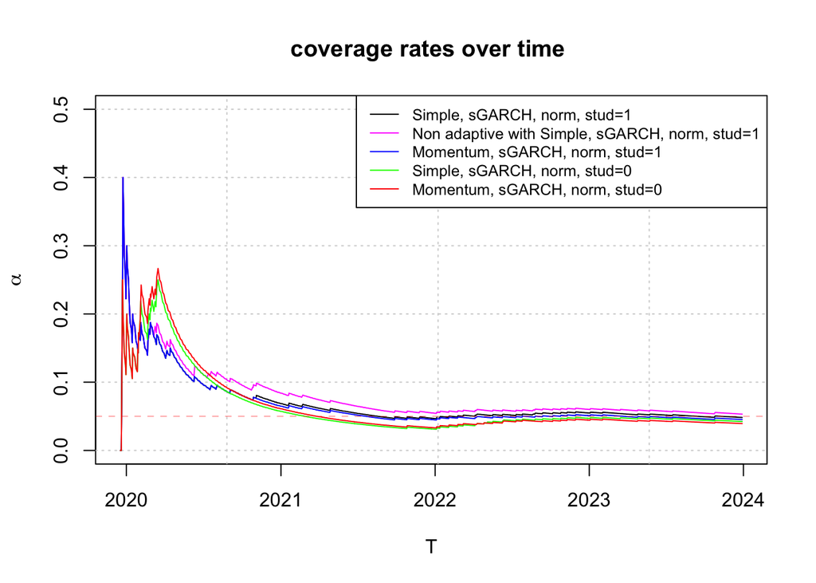

```r
plot(date, cummean(errSeqOC), ylim = c(0, 0.5), type= "l" , col= "black",
     main = "coverage rates over time ", xlab = "T", ylab = expression(alpha));grid()
points(date, cummean(errSeqNC), type= "l", col="magenta")
points(date, cummean(errSeqOC2), type= "l", col="blue")
points(date, cummean(errSeqOC3), type= "l", col="green")
points(date, cummean(errSeqOC4), type= "l", col="red")
abline(h = 0.05, col = "red", lwd = 0.3, lty = 2)

legend("topright", legend = c(
  "Simple, sGARCH, norm, stud=1",
  "Non adaptive with Simple, sGARCH, norm, stud=1",
  "Momentum, sGARCH, norm, stud=1",
  "Simple, sGARCH, norm, stud=0",
  "Momentum, sGARCH, norm, stud=0"
), col = c("black", "magenta", "blue", "green", "red"), lty = 1, cex = 0.8)
```

The non-normalized score amplifies the influence of extreme events and distributional shifts, resulting in frequent oscillations in $err_t$. These oscillations destabilize the algorithm and cause significant fluctuations in the coverage rate. From the graph, it is evident that the absence of normalization leads to greater instability in the coverage rate, characterized by large and erratic variations.

As noted by the authors of the paper, adopting the “momentum” strategy instead of the classical approach does not produce notable differences in the results.

```r
a_results <- garchConformalForcasting(returns = returns, alpha = 0.05, gamma = 0.003,lookback=lookback,garchP=1,garchQ=1,startUp = 100,
                                      verbose=FALSE,updateMethod="Simple", garchType = "eGARCH",noise="std",stud=1,armap=1,armaq=1)

a_results2 <- garchConformalForcasting(returns = returns, alpha = 0.05, gamma = 0.003,lookback=lookback,garchP=1,garchQ=1,startUp = 100,
                                       verbose=FALSE,updateMethod="Momentum", garchType = "eGARCH",noise="std",stud=1,armap=1,armaq=1)

a_results3 <- garchConformalForcasting(returns = returns, alpha = 0.05, gamma = 0.003,lookback=lookback,garchP=1,garchQ=1,startUp = 100,
                                       verbose=FALSE,updateMethod="Simple", garchType = "eGARCH",noise="std",stud=0,armap=1,armaq=1)

a_results4 <- garchConformalForcasting(returns = returns, alpha = 0.05, gamma = 0.003,lookback=lookback,garchP=1,garchQ=1,startUp = 100,
                                       verbose=FALSE,updateMethod="Momentum", garchType = "eGARCH",noise="std",stud=0,armap=1,armaq=1)

a_errSeqOC <- a_results[[2]]
mean(a_errSeqOC)
```

```
## [1] 0.05024631
```

```r
a_errSeqNC <- a_results[[3]]
mean(a_errSeqNC)
```

```
## [1] 0.05418719
```

```r
a_errSeqOC2 <- a_results2[[2]]
mean(a_errSeqOC2)
```

```
## [1] 0.04827586
```

```r
a_errSeqOC3 <- a_results3[[2]]
mean(a_errSeqOC3)
```

```
## [1] 0.04137931
```

```r
a_errSeqOC4 <- a_results4[[2]]
mean(a_errSeqOC4)
```

```
## [1] 0.03940887
```

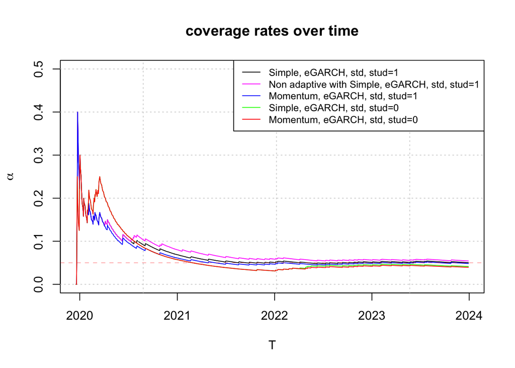

```r
plot(date, cummean(a_errSeqOC), ylim = c(0, 0.5), type= "l" , col= "black",
     main = "coverage rates over time", xlab = "T", ylab = expression(alpha));grid()
points(date, cummean(a_errSeqNC), type= "l", col="magenta")
points(date, cummean(a_errSeqOC2), type= "l", col="blue")
points(date, cummean(a_errSeqOC3), type= "l", col="green")
points(date, cummean(a_errSeqOC4), type= "l", col="red")
abline(h = 0.05, col = "red", lwd = 0.3, lty = 2)

legend("topright", legend = c(
  "Simple, eGARCH, std, stud=1",
  "Non adaptive with Simple, eGARCH, std, stud=1",
  "Momentum, eGARCH, std, stud=1",
  "Simple, eGARCH, std, stud=0",
  "Momentum, eGARCH, std, stud=0"
), col = c("black", "magenta", "blue", "green", "red"), lty = 1, cex = 0.8)
```

```r
gamma_values <- c(0.001, 0.005)

results_gamma <- list()
for (gamma in gamma_values) {
  print(paste("I'm using gamma =", gamma))
  results_gamma[[as.character(gamma)]] <- garchConformalForcasting(
    returns = returns, alpha = 0.05, gamma = gamma,
    lookback = 1250, garchP = 1, garchQ = 1,
    startUp = 100, updateMethod="Simple", garchType = "sGARCH",noise="norm",stud=1,armap=0,armaq=0)

}
```

```
## [1] "I'm using gamma = 0.001"
## [1] "I'm using gamma = 0.005"
```

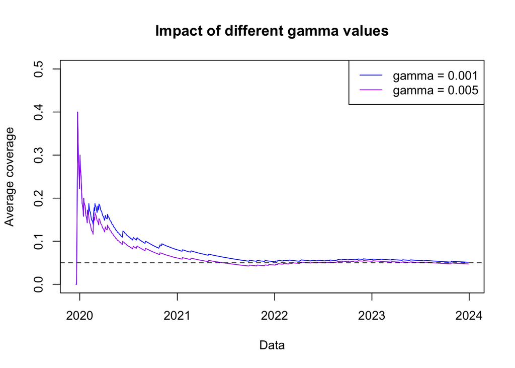

```r
plot(date, cummean(results_gamma[["0.001"]][[2]]), type = "l", col = "blue", ylim = c(0, 0.5),
     main = "Impact of different gamma values", xlab = "Data", ylab = "Average coverage")
lines(date, cummean(results_gamma[["0.005"]][[2]]), col = "purple")
abline(h = 0.05, col = "black", lty = 2)
legend("topright", legend = c("gamma = 0.001", "gamma = 0.005"),
       col = c("blue", "purple"), lty = 1)
```

We observe that as $\gamma$ increases, the coverage improves since the method becomes more responsive and better adapts to observed distribution shifts.

However, for values of $\gamma = 0.01$ or larger, the following error may occur:

```r
Error in quantile.default(recentScores, 1 - alphat): 'probs' outside [0,1]
```

This error indicates that the value calculated for $1 - \alpha_t$ in the quantile computation falls outside the valid range $[0,1]$. This happens because $\alpha_t$ becomes negative during the dynamic update. The error could also occur if $\alpha_t$ exceeds 1 during the update, although this is rare since $\alpha$ is small.

The issue arises from the high value of $\gamma$, which causes the update of $\alpha_t$ to be too sensitive, pushing it outside the valid range $[0,1]$.